# Member D: Numerical EDA of NQS Rating Tiers

STAT5003 Group 2 - Member D contribution

## Numerical predictors (Member D)

```r
source('R/04_eda_numerical.R')
```

The analysis uses the **17,160 labelled services** prepared by Members A/B. Four numerical predictors describe capacity, service approval age, provider approval age and provider scale. Ages use the fixed snapshot date of 18 September 2026; they measure years since recorded approval, not necessarily years of actual operation. Provider scale counts all registered services attached to the provider, including unlabelled services. All summaries below are service-weighted and use available observations, without imputation.

```r
d_display <- d_by_tier |>
  mutate(Variable = factor(variable, levels=d_vars,
    labels=c('Approved places','Service approval age (years)',
             'Provider approval age (years)','Provider service count')),
    summary=sprintf('%.1f [%.1f, %.1f]',median,q1,q3)) |>
  select(Variable,rating_tier,summary) |>
  pivot_wider(names_from=rating_tier,values_from=summary) |> arrange(Variable)
knitr::kable(d_display,caption='Median [Q1, Q3] by rating tier (original units).')
```

Median [Q1, Q3] by rating tier (original units).

| Variable | Below NQS | Meeting NQS | Above NQS |
| --- | --- | --- | --- |
| Approved places | 60.0 [39.0, 90.0] | 64.0 [40.0, 91.0] | 54.0 [35.0, 79.0] |
| Service approval age (years) | 13.6 [6.8, 14.7] | 14.7 [7.9, 14.7] | 14.7 [14.6, 16.0] |
| Provider approval age (years) | 13.1 [8.2, 14.7] | 14.1 [9.3, 14.7] | 14.7 [14.1, 15.7] |
| Provider service count | 2.0 [1.0, 20.0] | 8.0 [1.0, 76.0] | 4.0 [1.0, 56.0] |

**Distributions and missingness.** Approved places range from 6 to 477 (median 60; mean 69.6). All 307 Family Day Care services lack this field, while all 16,853 Centre-Based Care services have it; therefore, capacity comparisons describe Centre-Based Care only. One service approval age is missing; provider age and scale are complete. Provider scale is strongly right-skewed (median 7, mean 85.0, maximum 611). The 1.5-IQR rule flags 388 capacity values and 2,811 service rows for provider scale; these are screening flags, not evidence of erroneous records. Large providers recur across services. Across the 6,885 distinct providers represented in the labelled data, median provider scale is only 1 (mean 2.59), illustrating the effect of service weighting. Approval ages are concentrated around 14.7 years: the full raw register records 1 January 2012 for 6,071 service approvals. This date clustering requires caution when interpreting age as experience.

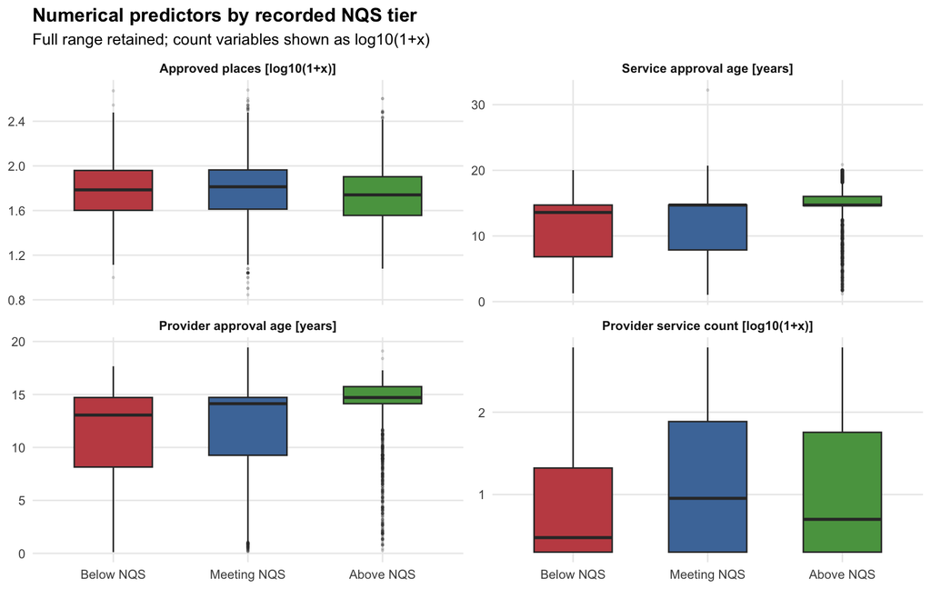

```r
d_rating_plot
```

**Relationships with rating tier.** Above NQS services have a smaller median capacity (54 places) than Meeting NQS (64) and Below NQS (60), with considerable overlap. Above NQS services also have a higher lower quartile of service approval age (14.62 years versus 7.87 and 6.83 years), although the Meeting and Above medians are both 14.71 years. Median provider age increases from 13.06 to 14.13 to 14.71 years across Below, Meeting and Above NQS. Provider scale is not monotonically related to the ordered tiers: the respective medians are 2, 8 and 4. These patterns motivate multivariable classification, but do not establish causation or out-of-sample predictive performance.

**Relationships among predictors and modelling implications.** Service and provider ages have a moderate positive Spearman correlation (rho = 0.421); capacity and service age are negatively associated (rho = -0.266). The remaining pairwise correlations have absolute values below 0.13. No pair warrants automatic removal solely on this evidence. Within-service-type summaries retain the general age pattern, while the Family Day Care subgroup is small (307) and lacks capacity data. Preserve service type and structural capacity missingness; use an explicit not-recorded indicator with a documented algorithm-compatible placeholder if needed, rather than interpreting absence as zero capacity. Any estimated imputation, transformations and scaling must be learned within training folds. Compare log1p count transformations for scale-sensitive models and retain plausible extremes unless source checks identify errors. Because services share providers, evaluate a provider-grouped split for generalisation to unseen providers and specify whether deployment concerns existing or new providers. The descriptive EDA uses the complete labelled snapshot, so a later holdout from this same snapshot is not wholly untouched by exploration. Exclude identifiers and all rating-derived predictors; judge classification using macro-F1 and per-class recall alongside accuracy and a majority-class baseline (74.29%).

## Supporting checks (keep outside the six-page group report)

```r
knitr::kable(d_profile |> select(variable,observed,missing,min,median,mean,max,iqr_flags),digits=2)
```

| variable | observed | missing | min | median | mean | max | iqr_flags |
| --- | --- | --- | --- | --- | --- | --- | --- |
| number_approved_places | 16853 | 307 | 6.00 | 60.00 | 69.61 | 477.00 | 388 |
| provider_age_years | 17160 | 0 | 0.12 | 14.35 | 12.35 | 19.44 | 93 |
| provider_service_count | 17160 | 0 | 1.00 | 7.00 | 84.97 | 611.00 | 2811 |
| service_age_years | 17159 | 1 | 1.04 | 14.71 | 12.37 | 32.22 | 1 |

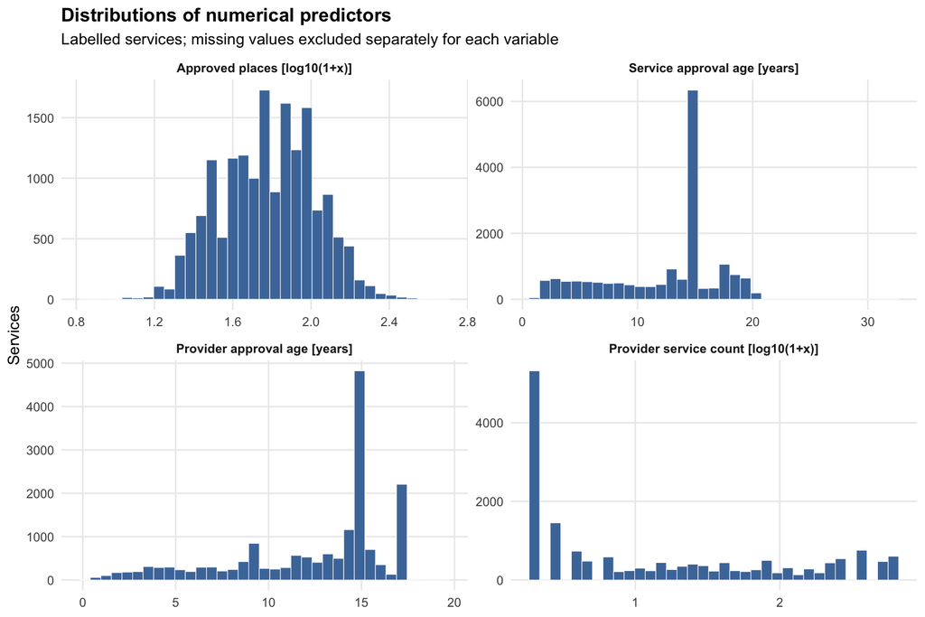

```r
d_distribution_plot
```

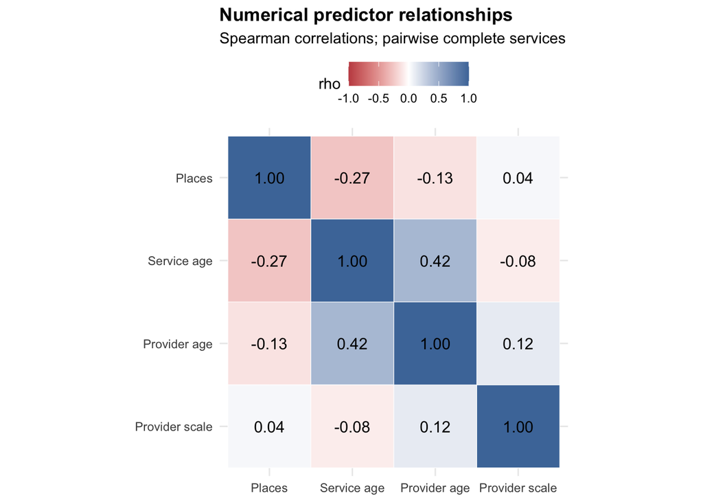

```r
d_correlation_plot
```

```r
knitr::kable(d_cor,digits=3,caption='Pairwise complete sample sizes and Spearman correlations.')
```

Pairwise complete sample sizes and Spearman correlations.

| var1 | var2 | n_complete | spearman |
| --- | --- | --- | --- |
| number_approved_places | service_age_years | 16852 | -0.266 |
| number_approved_places | provider_age_years | 16853 | -0.128 |
| number_approved_places | provider_service_count | 16853 | 0.040 |
| service_age_years | provider_age_years | 17159 | 0.421 |
| service_age_years | provider_service_count | 17159 | -0.083 |
| provider_age_years | provider_service_count | 17160 | 0.116 |

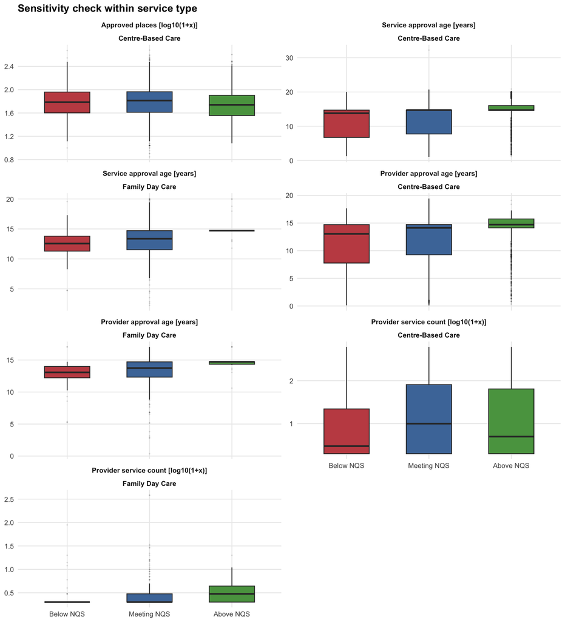

```r
d_type_plot
```

The Family Day Care capacity panel is absent because no values are recorded. These subgroup checks do not adjust for state, service offerings or other potential confounders. They are descriptive rather than hypothesis tests: repeated services within providers violate the independence assumed by simple unclustered tests.

```r
knitr::kable(d_date_peaks,caption='Most common approval dates in the full raw registers.')
```

Most common approval dates in the full raw registers.

| date | n | register |
| --- | --- | --- |
| 01/01/2012 | 1362 | All providers |
| 01/09/2009 | 1164 | All providers |
| 29/12/2011 | 1069 | All providers |
| 01/08/2012 | 216 | All providers |
| 25/09/2025 | 27 | All providers |
| 01/01/2012 | 6071 | All services |
| 20/07/2012 | 54 | All services |
| 23/01/2026 | 31 | All services |
| 16/03/2010 | 27 | All services |
| 25/01/2022 | 24 | All services |

## Optional individual model proposal: Random forest

This is a **provisional model choice for team coordination**, not a fitted result. A random forest is suitable for exploring nonlinear relationships and interactions among age, capacity, provider scale and categorical predictors. It does not require numerical standardisation. Retain service type, encode categorical values consistently, and handle missing values within each training fold, distinguishing the structurally unrecorded capacity of Family Day Care. Exclude all rating-derived variables and the two IDs from predictors, while retaining provider ID for grouped resampling.

Use a fixed sufficiently large forest (for example, 500 trees) and tune the number of candidate predictors per split and minimum terminal-node size; compare unweighted fitting with class weighting selected by training-only validation. Use macro-F1 as the primary tuning criterion and report recall for each tier, a confusion matrix and accuracy against the majority baseline. Provider-grouped evaluation should be used when the intended task is prediction for unseen providers. Strengths include flexible effects and interactions; limitations include reduced interpretability, possible majority-class dominance and difficulty extrapolating beyond observed predictor ranges. Importance scores describe predictive contribution and must not be interpreted as causal effects. The proposal must be coordinated with other members to avoid duplicate model choices.

The proposed implementation is R package `ranger`; its documented controls include `num.trees`, `mtry`, `min.node.size` and `class.weights` ([official package manual](https://cran.r-project.org/web/packages/ranger/ranger.pdf)).

## Full runnable analysis code

```r
# Member D: run from the repository root with Rscript R/04_eda_numerical.R
# Uses A/B's processed data unchanged; no imputation or model fitting during EDA.
required <- c('readr', 'dplyr', 'tidyr', 'ggplot2')
missing <- required[!vapply(required, requireNamespace, logical(1), quietly=TRUE)]
if (length(missing)) stop('Install packages: ', paste(missing, collapse=', '))
library(readr)
library(dplyr)
library(tidyr)
library(ggplot2)
if (!file.exists('data/processed/acecqa_analysis.csv')) source('R/01_prepare_data.R')
d_data <- read_csv('data/processed/acecqa_analysis.csv', show_col_types=FALSE)
d_tiers <- c('Below NQS','Meeting NQS','Above NQS')
d_vars <- c('number_approved_places','service_age_years','provider_age_years','provider_service_count')
d_labels <- c('Approved places [log10(1+x)]','Service approval age [years]',
              'Provider approval age [years]','Provider service count [log10(1+x)]')
stopifnot(!anyDuplicated(d_data$service_id), !anyNA(d_data$rating_tier),
          all(d_data$rating_tier %in% d_tiers), all(d_vars %in% names(d_data)))
d_data$rating_tier <- factor(d_data$rating_tier, levels=d_tiers)
d_long <- d_data |> select(service_id,provider_id,service_type,rating_tier,all_of(d_vars)) |>
  pivot_longer(all_of(d_vars), names_to='variable',values_to='value')
d_summary <- function(x) {
  v <- x[is.finite(x)]
  if (!length(v)) return(tibble(n=length(x),observed=0L,missing=sum(is.na(x)),
    missing_percent=100*mean(is.na(x)),min=NA_real_,q1=NA_real_,median=NA_real_,
    q3=NA_real_,max=NA_real_,mean=NA_real_,sd=NA_real_,iqr_flags=0L,negative=0L,zero=0L))
  q <- quantile(v,c(.25,.5,.75),names=FALSE)
  tibble(n=length(x),observed=length(v),missing=sum(is.na(x)),
    missing_percent=100*mean(is.na(x)),min=min(v),q1=q[1],median=q[2],q3=q[3],
    max=max(v),mean=mean(v),sd=sd(v),
    iqr_flags=sum(v<q[1]-1.5*(q[3]-q[1]) | v>q[3]+1.5*(q[3]-q[1])),
    negative=sum(v<0),zero=sum(v==0))
}
d_profile <- d_long |> group_by(variable) |> group_modify(~d_summary(.x$value)) |> ungroup()
d_by_tier <- d_long |> group_by(variable,rating_tier) |> group_modify(~d_summary(.x$value)) |> ungroup()
d_by_type <- d_long |> group_by(variable,service_type,rating_tier) |>
  group_modify(~d_summary(.x$value)) |> ungroup()
d_missing_type <- d_long |> group_by(variable,service_type) |> summarise(
  n=n(),missing=sum(is.na(value)),missing_percent=100*mean(is.na(value)),.groups='drop')
# Service-level correlations: provider attributes are repeated for each linked service.
d_pairs <- combn(d_vars,2,simplify=FALSE)
d_cor <- bind_rows(lapply(d_pairs,function(v) {
  ok <- complete.cases(d_data[,v]); x <- d_data[[v[1]]][ok]; y <- d_data[[v[2]]][ok]
  tibble(var1=v[1],var2=v[2],n_complete=sum(ok),spearman=cor(x,y,method='spearman'))
}))
# Provider-level sensitivity summary; one record per represented provider.
d_providers <- d_data |> distinct(provider_id,provider_age_years,provider_service_count)
stopifnot(!anyDuplicated(d_providers$provider_id))
d_provider_profile <- d_providers |> pivot_longer(-provider_id,names_to='variable',values_to='value') |>
  group_by(variable) |> group_modify(~d_summary(.x$value)) |> ungroup()
# Fixed descriptive bins, not fitted cut points or mandatory modelling categories.
d_scale_mix <- d_data |> mutate(scale_band=cut(provider_service_count,
  breaks=c(0,1,5,20,100,Inf),labels=c('1','2-5','6-20','21-100','101+'))) |>
  count(scale_band,rating_tier,.drop=FALSE) |> group_by(scale_band) |>
  mutate(total=sum(n),percent=100*n/total) |> ungroup()
d_extremes <- d_long |> filter(!is.na(value)) |> group_by(variable) |>
  slice_max(value,n=5,with_ties=FALSE) |> ungroup()
d_plot_data <- d_long |> mutate(panel=factor(variable,levels=d_vars,labels=d_labels),
  plotted=if_else(variable %in% d_vars[c(1,4)],log10(1+pmax(value,0)),value))
d_cols <- c('Below NQS'='#C44E52','Meeting NQS'='#4C78A8','Above NQS'='#59A14F')
d_theme <- theme_minimal(base_size=11)+theme(legend.position='top',panel.grid.minor=element_blank(),
  strip.text=element_text(face='bold'),plot.title=element_text(face='bold'))
d_distribution_plot <- ggplot(filter(d_plot_data,!is.na(plotted)),aes(plotted))+
  geom_histogram(bins=35,fill='#4C78A8',colour='white',linewidth=.2)+
  facet_wrap(~panel,scales='free',ncol=2)+labs(title='Distributions of numerical predictors',
  subtitle='Labelled services; missing values excluded separately for each variable',x=NULL,y='Services')+d_theme
# Full range retained; transformed axes compress the tails without dropping services.
d_rating_plot <- ggplot(filter(d_plot_data,!is.na(plotted)),aes(rating_tier,plotted,fill=rating_tier))+
  geom_boxplot(width=.58,outlier.size=.45,outlier.alpha=.15)+
  facet_wrap(~panel,scales='free_y',ncol=2)+scale_fill_manual(values=d_cols)+
  labs(title='Numerical predictors by recorded NQS tier',
  subtitle='Full range retained; count variables shown as log10(1+x)',x=NULL,y=NULL)+d_theme+
  theme(legend.position='none')
d_type_plot <- ggplot(filter(d_plot_data,!is.na(plotted)),aes(rating_tier,plotted,fill=rating_tier))+
  geom_boxplot(width=.55,outlier.size=.3,outlier.alpha=.1)+
  facet_wrap(vars(panel,service_type),scales='free_y',ncol=2)+scale_fill_manual(values=d_cols)+
  labs(title='Sensitivity check within service type',x=NULL,y=NULL)+d_theme+theme(legend.position='none')
d_cor_grid <- bind_rows(d_cor |> select(var1,var2,spearman),
  d_cor |> select(var1=var2,var2=var1,spearman),tibble(var1=d_vars,var2=d_vars,spearman=1))
stopifnot(nrow(distinct(d_cor_grid,var1,var2)) == 16L)
d_short <- c('Places','Service age','Provider age','Provider scale')
d_cor_grid <- d_cor_grid |> mutate(var1=factor(var1,levels=d_vars,labels=d_short),
  var2=factor(var2,levels=rev(d_vars),labels=rev(d_short)))
d_correlation_plot <- ggplot(d_cor_grid,aes(var1,var2,fill=spearman))+geom_tile(colour='white')+
  geom_text(aes(label=sprintf('%.2f',spearman)),size=4)+
  scale_fill_gradient2(low='#C44E52',mid='white',high='#4C78A8',limits=c(-1,1))+
  coord_equal()+labs(title='Numerical predictor relationships',
  subtitle='Spearman correlations; pairwise complete services',x=NULL,y=NULL,fill='rho')+d_theme

dir.create('outputs/numerical',recursive=TRUE,showWarnings=FALSE)
dir.create('figures',showWarnings=FALSE)
for (nm in c('profile','by_tier','by_type','missing_type','cor','provider_profile','scale_mix','extremes'))
  write_csv(get(paste0('d_',nm)),paste0('outputs/numerical/',nm,'.csv'),na='')
ggsave('figures/numerical_distributions.png',d_distribution_plot,width=9,height=6,dpi=180)
ggsave('figures/numerical_by_rating.png',d_rating_plot,width=9,height=6,dpi=180)
ggsave('figures/numerical_by_service_type.png',d_type_plot,width=10,height=11,dpi=180)
ggsave('figures/numerical_correlations.png',d_correlation_plot,width=7,height=5,dpi=180)
print(d_profile,width=Inf)
print(d_by_tier |> select(variable,rating_tier,observed,missing,median,q1,q3),n=20)
print(d_cor)
print(d_missing_type)
print(d_provider_profile,width=Inf)
# Audit upstream definitions against raw registers (read all columns as text).
d_raw_s <- read_csv('Education-services-au-export.csv',col_types=cols(.default=col_character()))
d_raw_p <- read_csv('Approved-providers-au-export.csv',col_types=cols(.default=col_character()))
d_raw_scale <- d_raw_s |> count(`Provider Approval Number`,name='expected_scale')
d_check <- d_data |> left_join(d_raw_scale,by=c('provider_id'='Provider Approval Number'))
stopifnot(all(d_check$provider_service_count==d_check$expected_scale),
  nrow(d_data)==sum(!is.na(d_raw_s$OverallRating)),
  all(vapply(d_data[d_vars],function(x) all(is.finite(x)|is.na(x)),logical(1))))
d_date_peaks <- bind_rows(
  d_raw_s |> count(ServiceApprovalGrantedDate,name='n') |> rename(date=ServiceApprovalGrantedDate) |>
    mutate(register='All services'),
  d_raw_p |> count(`Date Approval Granted`,name='n') |> rename(date=`Date Approval Granted`) |>
    mutate(register='All providers')) |> group_by(register) |> slice_max(n,n=5,with_ties=FALSE) |> ungroup()
write_csv(d_date_peaks,'outputs/numerical/approval_date_peaks.csv')
```

## Reproducibility and AI disclosure

The analysis script is `R/04_eda_numerical.R`; its input is the unmodified A/B dataset `data/processed/acecqa_analysis.csv`. The preparation branch used was `ab-data-preparation`, commit `2e553ab4140bf8017522cd749b819298efefedd6`. C’s submitted code was inspected for compatibility but is not duplicated here. Numerical results and figures are regenerated when this document is knitted. This is a standalone contribution with supporting detail, not the final six-page group submission.

Suggested disclosure to review and incorporate: OpenAI Codex was used to help write and execute numerical EDA code, prepare visualisations and draft interpretation and modelling suggestions. The submitting student should review the code, results and final wording and take responsibility for the submitted contribution.